# IRS analysis of Haifeng’s data

This document details the analysis of proteomics data acquired to look at A673 cells in 2D and 3D growth conditions with modulation of EWS-FLI1. We want to make comparisons between batches, so we need to do some sort of normalization to facilitate that. The purpose of the work below is to use the Internal Reference Scaling method. This method is discussed in great detail on the [GitHub page](https://github.com/pwilmart/IRS_normalization) of Phil Wilmart. I strongly encourage you to visit his site, as it is a fantastic resource for all things proteomic!

## Setting up the environment

These are packages you will need for this notebook. For exact versions used, please refer to the session info at the bottom of this notebook.

```r
##########################################################################################
library('tidyverse')
library('ggplot2')
library('RColorBrewer')
library('limma')
library('edgeR')
```

I want to set a base directory that we can use as a link to the directory where we will do most of the work. I use two directories here because the Workspace is what is pushed to GitHub and contains scripts and plot files, but the Repository is where more of the big data is stored that does not get pushed.

```r
##########################################################################################
generalDatasets = 'C:/Users/chughes/Documents/bccrc/projectsRepository/generalDatasets'
baseWorkspace = 'C:/Users/chughes/Documents/bccrc/projectsWorkspace/sorensenLab/relatedToOthers'
baseRepository = 'C:/Users/chughes/Documents/bccrc/projectsRepository/sorensenLab/relatedToOthers'
#generalDatasets = 'C:/Users/chris/OneDrive/Documents/bccrc/projectsRepository/generalDatasets'
#baseWorkspace = 'C:/Users/chris/OneDrive/Documents/bccrc/projectsWorkspace/sorensenLab/relatedToYbx1'
#baseRepository = 'C:/Users/chris/OneDrive/Documents/bccrc/projectsRepository/sorensenLab/relatedToYbx1'
```

## Data processing

Read the protein data sets. There are two sets in total for this experiment.

```r
##########################################################################################
proteinSet1 = readRDS(paste(baseRepository, '/proteomics20201115_haifengA673Dox2d3dSetA/dataset_proteinSet2d.rds', sep = ''))
proteinSet2 = readRDS(paste(baseRepository, '/proteomics20201115_haifengA673Dox2d3dSetB/dataset_proteinSet3d.rds', sep = ''))
proteinSet = proteinSet1 %>%
  left_join(proteinSet2)
```

Start with the sum data and work through the IRS analysis.

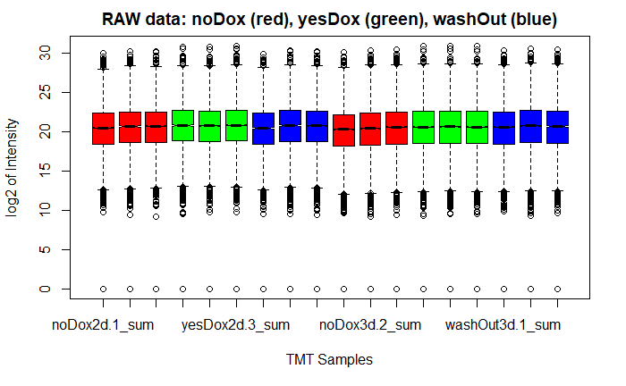

```r
##########################################################################################
rawData = proteinSet[,c(which(grepl('_sum', colnames(proteinSet))))]
rawData = rawData[,c(1,11:12,22,2:10,13:21)]
rawData[rawData == 0] = NA
rawData$accession = proteinSet$accession
rawData = subset(rawData, rowSums(is.na(rawData[,5:13])) < 9 & rowSums(is.na(rawData[,14:22])) < 9)
rawData[is.na(rawData)] = 1
##
boxplot(log2(rawData[,5:22]), col = rep(rep(c('red', 'green', 'blue'), each = 3), 2),
        notch = TRUE, main = 'RAW data: noDox (red), yesDox (green), washOut (blue)',
        xlab = 'TMT Samples', ylab = 'log2 of Intensity')
```

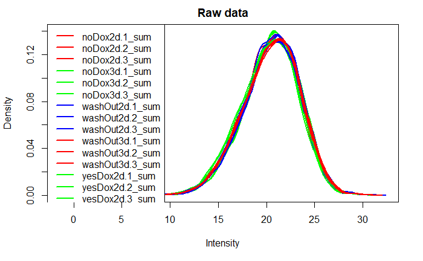

```r
##
plotDensities(log2(rawData[,5:22]), col = rep(rep(c('red', 'green', 'blue'), each = 3), 2),
              main = 'Raw data')
```

The data actually look pretty tight already. Check for column totals.

```r
##########################################################################################
format(round(colSums(rawData[,5:22], na.rm = TRUE), digits = 0), big.mark = ",")
```

```
   noDox2d.1_sum    noDox2d.2_sum    noDox2d.3_sum   yesDox2d.1_sum   yesDox2d.2_sum   yesDox2d.3_sum  washOut2d.1_sum  washOut2d.2_sum  washOut2d.3_sum
"57,214,998,039" "66,799,958,348" "65,879,334,898" "77,546,004,135" "74,737,543,336" "78,152,471,934" "56,236,470,633" "72,588,484,893" "68,277,303,203"
   noDox3d.1_sum    noDox3d.2_sum    noDox3d.3_sum   yesDox3d.1_sum   yesDox3d.2_sum   yesDox3d.3_sum  washOut3d.1_sum  washOut3d.2_sum  washOut3d.3_sum
"53,281,638,903" "60,295,269,465" "65,077,096,799" "73,462,905,424" "74,193,060,200" "72,250,492,775" "64,641,131,868" "75,111,526,600" "69,285,680,313"
```

Start off with the sample loading ‘SL’ normalization.

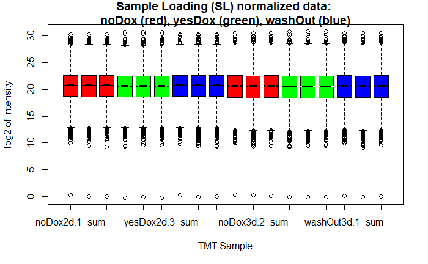

```r
##########################################################################################
# separate the TMT data by experiment
# we do not need to do this for the normalization factor calculation here,
# but we will need these data frames for the IRS step below.
exp1Raw = rawData[c(5:13)]
exp2Raw = rawData[c(14:22)]

# first basic normalization is to adjust each TMT experiment to equal signal per channel
# figure out the global scaling value
target = mean(c(colSums(exp1Raw, na.rm = TRUE), colSums(exp2Raw, na.rm = TRUE)))

# do the sample loading normalization before the IRS normalization
# there is a different correction factor for each column
normFacs = target / colSums(exp1Raw, na.rm = TRUE)
exp1Sl = sweep(exp1Raw, 2, normFacs, FUN = "*")
normFacs = target / colSums(exp2Raw, na.rm = TRUE)
exp2Sl = sweep(exp2Raw, 2, normFacs, FUN = "*")

# make a pre-IRS data frame after sample loading normalizations
dataSl = cbind(exp1Sl, exp2Sl)

# see what the SL normalized data look like
boxplot(log2(dataSl), col = rep(rep(c('red', 'green', 'blue'), each = 3), 2),
        notch = TRUE, main = "Sample Loading (SL) normalized data: \nnoDox (red), yesDox (green), washOut (blue)",
        xlab = 'TMT Sample', ylab = 'log2 of Intensity')
```

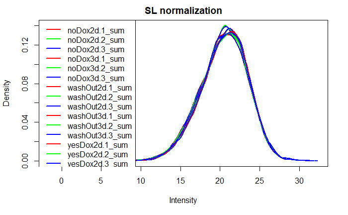

```r
# can also look at density plots (like a distribution histogram)
plotDensities(log2(dataSl), col = rep(c("red", "green", "blue"), 6), main = "SL normalization")
```

They look even tighter now. I think we can move onto IRS normalization now.

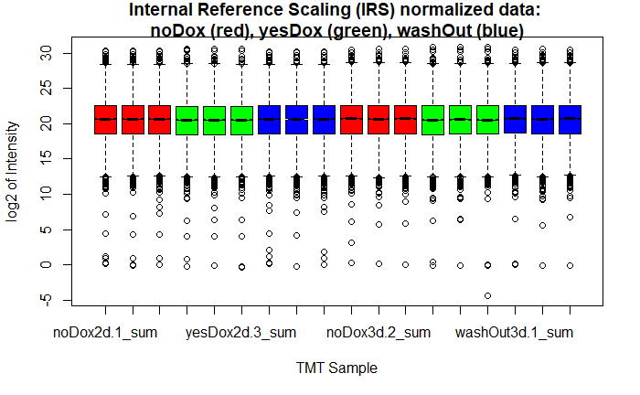

```r
##########################################################################################
# make new data frame with row sums from each frame
irs = tibble(rowSums(rawData[,1:2], na.rm = TRUE), rowSums(rawData[,3:4], na.rm = TRUE))
colnames(irs) = c('sum1','sum2')

# get the geometric average intensity for each protein
irs$average = apply(irs, 1, function(x) exp(mean(log(x),na.rm = TRUE)))

# compute the scaling factor vectors
irs$fac1 = irs$average / irs$sum1
irs$fac2 = irs$average / irs$sum2

# make new data frame with IRS normalized data
dataIrs = exp1Sl * irs$fac1
dataIrs = cbind(dataIrs, exp2Sl * irs$fac2)


# see what the IRS data look like
boxplot(log2(dataIrs), col = rep(rep(c('red', 'green', 'blue'), each = 3), 2),
        main = "Internal Reference Scaling (IRS) normalized data: \nnoDox (red), yesDox (green), washOut (blue)",
        xlab = 'TMT Sample', ylab = 'log2 of Intensity', notch = TRUE)
```

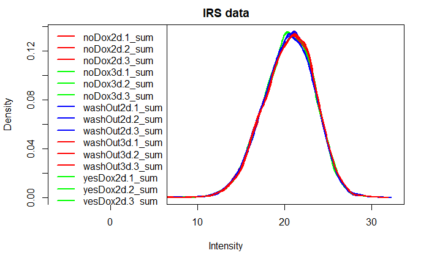

```r
# can also look at density plots (like a distribution histogram)
plotDensities(log2(dataIrs), col = rep(rep(c('red', 'green', 'blue'), each = 3), 2), main = "IRS data")
```

Now check the column totals again.

```r
##########################################################################################
format(round(colSums(dataIrs, na.rm = TRUE), digits = 0), big.mark = ",")
```

```
   noDox2d.1_sum    noDox2d.2_sum    noDox2d.3_sum   yesDox2d.1_sum   yesDox2d.2_sum   yesDox2d.3_sum  washOut2d.1_sum  washOut2d.2_sum  washOut2d.3_sum
"65,059,694,872" "65,085,323,602" "65,046,342,206" "65,026,657,211" "65,011,863,064" "65,026,827,926" "65,044,542,180" "65,054,892,268" "65,064,257,503"
   noDox3d.1_sum    noDox3d.2_sum    noDox3d.3_sum   yesDox3d.1_sum   yesDox3d.2_sum   yesDox3d.3_sum  washOut3d.1_sum  washOut3d.2_sum  washOut3d.3_sum
"69,225,975,643" "69,227,236,075" "69,234,898,121" "69,298,526,845" "69,328,192,038" "69,343,460,972" "69,227,664,534" "69,223,597,389" "69,249,355,925"
```

So, pretty close. Now, we apply TMM normalization, although I don’t really think it is going to change much in the data.

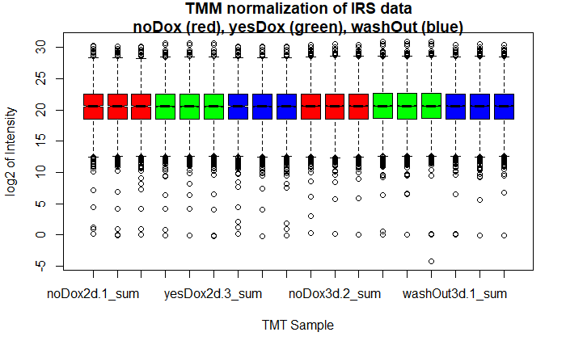

```r
##########################################################################################
# this is data after SL, IRS, and TMM normalized on original scale
irsTmm = calcNormFactors(dataIrs)
dataIrsTmm = sweep(dataIrs, 2, irsTmm, FUN = "/")

# see if box plots are aligned
boxplot(log2(dataIrsTmm), notch = TRUE, col = rep(rep(c('red', 'green', 'blue'), each = 3), 2),
        main = "TMM normalization of IRS data\nnoDox (red), yesDox (green), washOut (blue)",
        xlab = 'TMT Sample', ylab = 'log2 of Intensity')
```

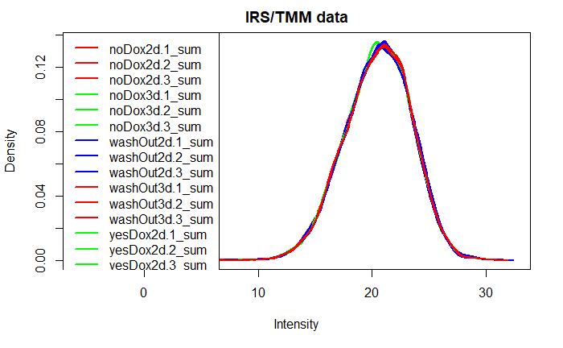

```r
# can also look at density plots (like a distribution histogram)
plotDensities(log2(dataIrsTmm), col = rep(rep(c('red', 'green', 'blue'), each = 3), 2), main = "IRS/TMM data")
```

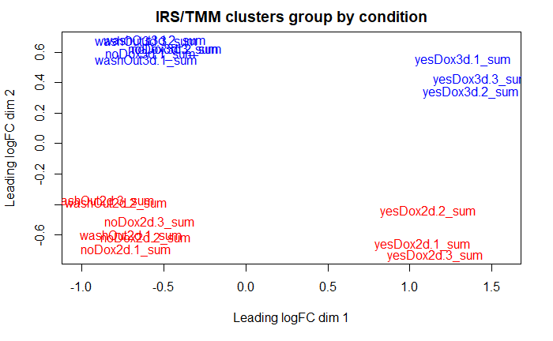

```r
# see how things cluster after IRS plus TMM
colVec = c(rep('red',9),rep('blue',9))
plotMDS(log2(dataIrsTmm), col = colVec, main = "IRS/TMM clusters group by condition")
```

It is not really clear if it has done anything, so take a quick look to see how it is without TMM.

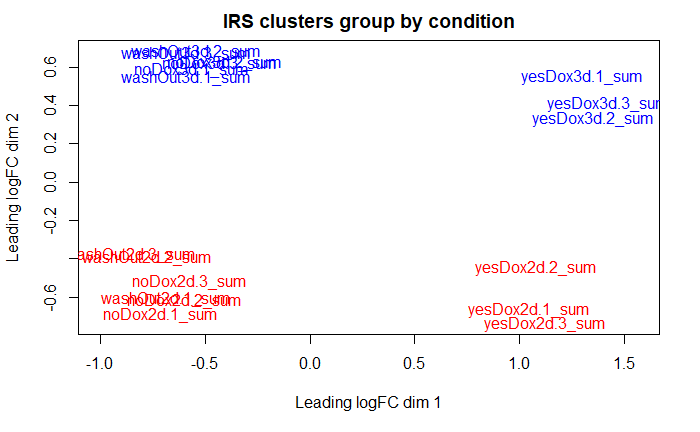

```r
##########################################################################################
# see how things cluster after IRS
colVec = c(rep('red',9),rep('blue',9))
plotMDS(log2(dataIrs), col = colVec, main = "IRS clusters group by condition")
```

So they are almost identical based on this. So I think I will exclude TMM as it just doesn’t seem necessary.

While this may look like they have separated by batch (they have), the batches are not technically the same, so this is not surprising. The first batch is 2D growth, and the second is 3D. So, I do not expect these to be identical. It is good to see that they to separate based on the condition, with noDox and washOut clustering together very nicely.

Recombine the data with the accessions and look at a few target proteins.

```r
##########################################################################################
proteinAnnotation = readRDS(paste(baseRepository, '/proteomics20201115_haifengA673Dox2d3dSetB/uniprotHumanNov2020.fasta.annotated.rds', sep = ''))
finalIrsData = as_tibble(cbind(rawData$accession, dataIrs)) %>%
  rename(accession = `rawData$accession`) %>%
  left_join(proteinAnnotation)
finalIrsData[grepl('IL1RAP', finalIrsData$gene),]
```

| accession | noDox2d.1_sum | noDox2d.2_sum | noDox2d.3_sum | yesDox2d.1_sum | yesDox2d.2_sum | yesDox2d.3_sum | washOut2d.1_sum | washOut2d.2_sum | washOut2d.3_sum | noDox3d.1_sum | noDox3d.2_sum | noDox3d.3_sum | yesDox3d.1_sum | yesDox3d.2_sum | yesDox3d.3_sum | washOut3d.1_sum | washOut3d.2_sum | washOut3d.3_sum | gene | species | length | detectablePeptides | detectableLength |
| --- | --- | --- | --- | --- | --- | --- | --- | --- | --- | --- | --- | --- | --- | --- | --- | --- | --- | --- | --- | --- | --- | --- | --- |
| Q9NPH3 | 5816548 | 5973319 | 7663530 | 2000434 | 2077878 | 2029727 | 9935401 | 6644070 | 7058303 | 5524303 | 5266872 | 5436281 | 1714747 | 1667906 | 1539919 | 5815405 | 5824260 | 5911328 | IL1RAP | human | 570 | 34 | 411 |

```r
##save data
saveRDS(finalIrsData, paste(baseRepository, '/proteomics20201115_haifengA673Dox2d3dSetB/dataset_proteinSet2d3dIrsNormalized.rds', sep = ''))
```

[session information not shown]